# simon-5502-04-slides

## Topics to be covered

- What you will learn
  - Review one factor analysis of variance
  - Multiple factor analysis of variance
  - Checking assumptions of analysis of variance
  - Interactions in analysis of variance

## Review oneway analysis of variance

- $H_0:\ \mu_1=\mu_2=...=\mu_k$
- $H_1:\ \mu_i \ne \mu_j$ for some i, j
  - Reject $H_0$ if F-ratio is large
- Note: when k=2, use analysis of variance or t-test

## Full moon data

- Admission rates to mental health clinic
  - Before, during, and after full moon.
- One year of data, starting in August
- Consult the [data dictionary](https://github.com/pmean/data/blob/main/files/full-moon-er-admissions.yaml) for more details

## Line graph of full moon data

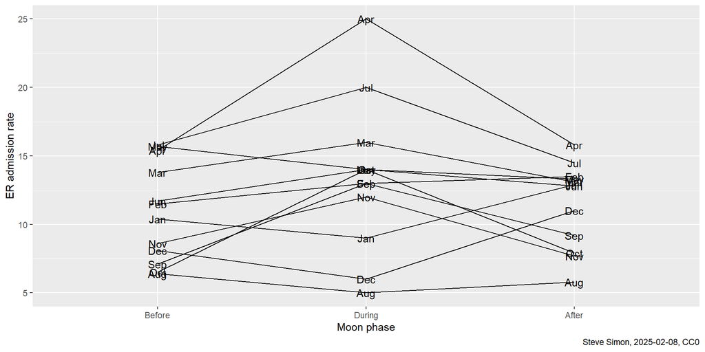

## Alternative line graph of full moon data

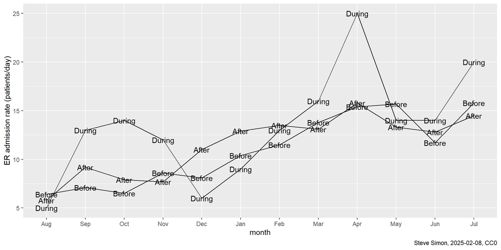

## Descriptive statistics by moon phase

```
# A tibble: 3 × 3
  moon   Admission_mean Admission_sd
  <fct>           <dbl>        <dbl>
1 Before           10.9         3.62
2 During           13.4         5.50
3 After            11.5         3.11
```

## Analysis of variance table

```
# A tibble: 2 × 7
  term             df.residual   rss    df sumsq statistic p.value
  <chr>                  <dbl> <dbl> <dbl> <dbl>     <dbl> <glue>
1 admission ~ 1             35  625.    NA  NA       NA    <NA>
2 admission ~ moon          33  583.     2  41.5      1.17 p = 0.322
```

## Parameter estimates

```
# A tibble: 3 × 5
  term        estimate std.error statistic p.value
  <chr>          <dbl>     <dbl>     <dbl> <glue>
1 (Intercept)   10.9        1.21     8.99  p < 0.001
2 moonDuring     2.50       1.72     1.46  p = 0.155
3 moonAfter      0.542      1.72     0.316 p = 0.754
```

## Live demo, Review one factor analysis of variance

Live demonstration of part 1 of simon-5502-04-demo.qmd

## Break #1

- What you have learned
  - Review one factor analysis of variance
- What’s coming next
  - Multiple factor analysis of variance

## Mathematical model, 1

- Decompose $\mu_{ij}$ into $\mu + \alpha_i + \beta_j$
  - $\alpha_i$ is the deviation for the ith level of first factor
  - $\beta_j$ is the deviation for the jth level of second factor
  - Require $\alpha_1=0$ and $\beta_1=0$
  - $\mu$ is the mean for the reference levels

## Mathematical model, 2

- $Y_{ijk} = \mu + \alpha_i + \beta_j +\epsilon_{ijk}$
  - i=1,…,a levels of the first categorical variable
  - j=1,…,b levels of the second categorical variable
  - k=1,…,n replicates with first and second categories
- Note: $\mu, \alpha_i, \beta_j, \epsilon_{ijk}$ are population values

## Mathematical model, 3

- $H_0:\ \alpha_i=0$ for all i

- $H_0:\ \beta_j=0$ for all j

## Testing the global hypothesis

- $H_0:\ \alpha_i=0,\ \beta_j=0$ for all i,j
- $H_1$: At least one $\alpha$ or $\beta$ $\ne$ 0

```
Model    rss        sumsq
null     SSE(null)  NA
full     SSE(full)  SSR(full)
                     = SSE(null)-SSE(full)

Note: SSE(null) is usually called SST or SS_Total.

Degrees of freedom = n-a-b+1, n-1, a+b-2
```

## The more traditional layout

```
            SS       df    MS
Regression  SSR    a+b-2   MSR = SSR/df
Error       SSE   n-a-b+1  MSE = SSE/df
Total       SST     n-1

F = MSR / MSE

SSR = SSR(full)
SSE = SSE(full)
SST = SSE(null)
```

## R-squared

- $R^2=\frac{explained\ variation}{total\ variation}= \frac{SSR(full)}{SSE(null)}$
- $R^2=1-\frac{unexplained\ variation}{total\ variation}= 1 - \frac{SSE(full)}{SSE(null)}$

## Testing the partial hypothesis

- $H_0:\ \beta_j=0$ for all j
- $H_1$: At least one $\beta$ $\ne$ 0

[output not shown]

## Partial R-squared

- $partial\ R^2=\frac{partial\ explained\ variation}{total\ variation}= \frac{SSR(full|partial)}{SSE(null)}=\frac{SSE(partial)-SSE(full)}{SSE(null)}$

## Parameter estimates for the two factor model

```
# A tibble: 14 × 5
   term        estimate std.error statistic p.value
   <chr>          <dbl>     <dbl>     <dbl> <glue>
 1 (Intercept)    4.72      1.50      3.14  p = 0.005
 2 moonDuring     2.5       0.984     2.54  p = 0.019
 3 moonAfter      0.542     0.984     0.550 p = 0.588
 4 monthSep       4.03      1.97      2.05  p = 0.053
 5 monthOct       3.73      1.97      1.90  p = 0.071
 6 monthNov       3.70      1.97      1.88  p = 0.073
 7 monthDec       2.63      1.97      1.34  p = 0.195
 8 monthJan       5.03      1.97      2.56  p = 0.018
 9 monthFeb       6.93      1.97      3.52  p = 0.002
10 monthMar       8.57      1.97      4.35  p < 0.001
11 monthApr      13.0       1.97      6.61  p < 0.001
12 monthMay       8.60      1.97      4.37  p < 0.001
13 monthJun       7.10      1.97      3.61  p = 0.002
14 monthJul      11.0       1.97      5.61  p < 0.001
```

## Analysis of variance table comparing the two factor model to the null model

```
# A tibble: 2 × 7
  term                     df.residual   rss    df sumsq statistic p.value
  <chr>                          <dbl> <dbl> <dbl> <dbl>     <dbl> <glue>
1 admission ~ 1                     35  625.    NA   NA      NA    <NA>
2 admission ~ moon + month          22  128.    13  497.      6.58 p < 0.001
```

## Analysis of variance table comparing the two factor model to the one factor model

```
# A tibble: 2 × 7
  term                     df.residual   rss    df sumsq statistic p.value
  <chr>                          <dbl> <dbl> <dbl> <dbl>     <dbl> <glue>
1 admission ~ moon                  33  583.    NA   NA      NA    <NA>
2 admission ~ moon + month          22  128.    11  456.      7.13 p < 0.001
```

## R-squared values

```
# A tibble: 3 × 3
  model      r.squared deviance
  <chr>          <dbl>    <dbl>
1 Null          0          625.
2 Moon          0.0664     583.
3 Moon Month    0.795      128.
```

## Tukey post hoc test

```
# A tibble: 3 × 7
  term  contrast      null.value estimate conf.low conf.high adj.p.value
  <chr> <chr>              <dbl>    <dbl>    <dbl>     <dbl> <chr>
1 moon  After-Before           0    0.542  -1.93        3.01 0.847
2 moon  During-Before          0    2.50    0.0280      4.97 0.047
3 moon  During-After           0    1.96   -0.514       4.43 0.138
```

## Live demo, Multiple factor analysis of variance

Live demonstration of part 2 of simon-5502-04-demo.qmd

## Break #2

- What you have learned
  - Multiple factor analysis of variance
- What’s coming next
  - Checking assumptions of analysis of variance

## Assumptions

- Normality
- Equal variances
- Independence
- Note: No linearity assumption
  - Only for linear regression and analysis of covariance

## Q-Q plot of residuals

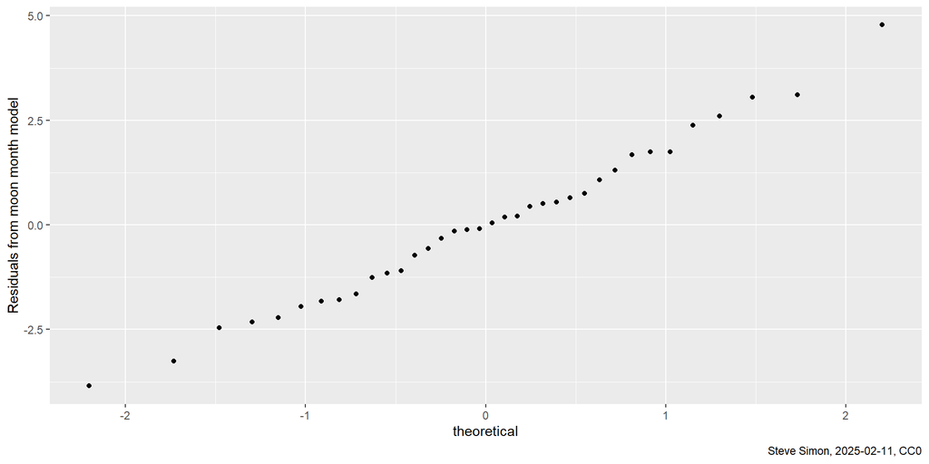

## Residual versus predicted value plot

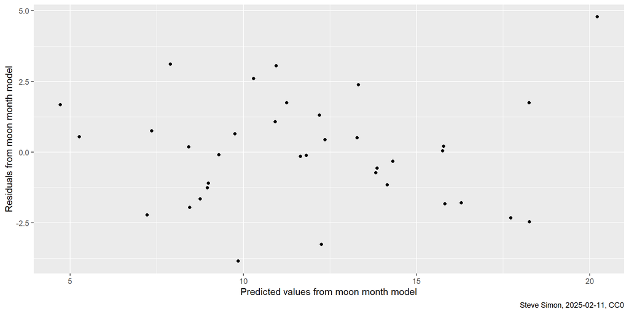

## Diagnostic measures that are not needed

- Variance inflation factor
- Leverage
- Studentized deleted residuals
- Cook’s distance

## Live demo, Checking assumptions of analysis of variance

Live demonstration of part 3 of simon-5502-04-demo.qmd

## Break #3

- What you have learned
  - Checking assumptions of analysis of variance
- What’s coming next
  - Interactions in analysis of variance

## What is an interaction

- Impact of one variable is influenced by a second variable
- Example, influence of alcohol on sleeping pills
- Three types of interactions
  - Between two categorical predictors
  - Between a categorical and a continuous predictor
  - Between two continuous predictors
- Interactions greatly complicate interpretation

## Interaction plot

- X axis, first categorical variable
- Separate lines for second categorical variable
- Y axis, average outcome

## Hypothetical interaction plots, 1 of 4

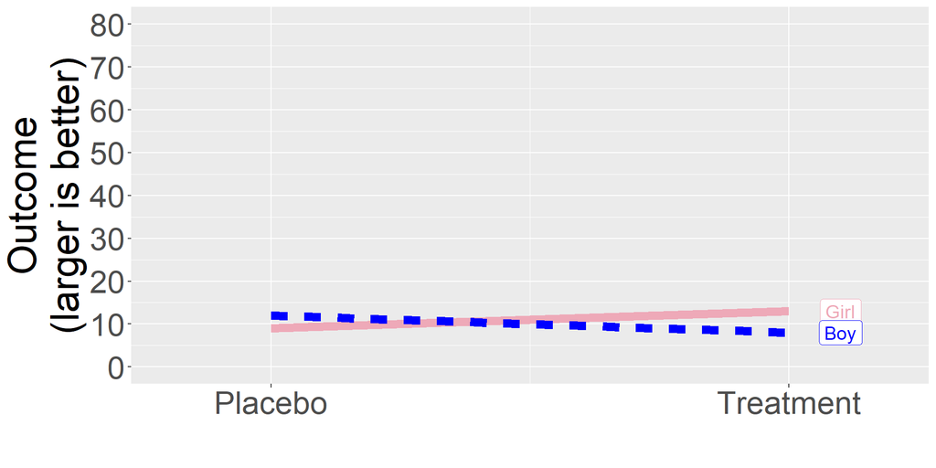

- No interaction
- Ineffective treatment
- Boys/girls similar

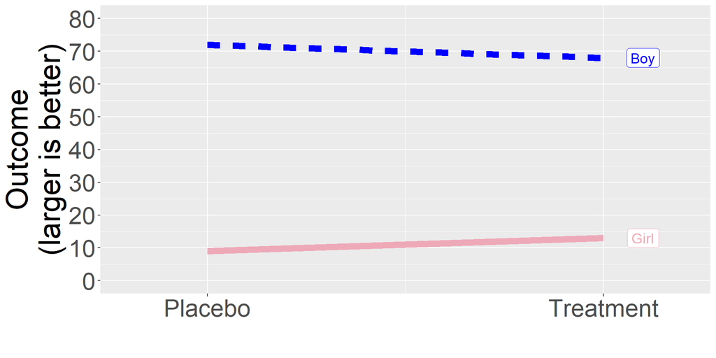

- No interaction
- Ineffective treatment
- Boys fare better than girls

## Hypothetical interaction plots, 2 of 4

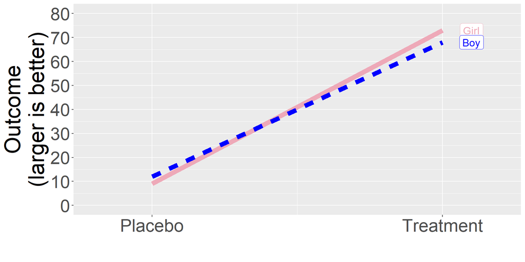

- No interaction
- Effective treatment
- Boys/girls similar

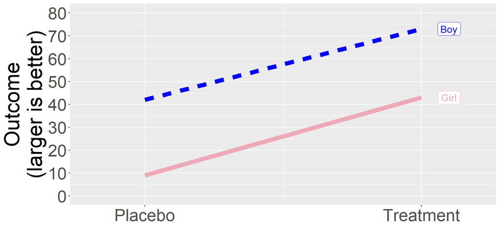

- No interaction
- Effective treatment
- Boys fare better than girls

## Hypothetical interaction plots, 3 of 4

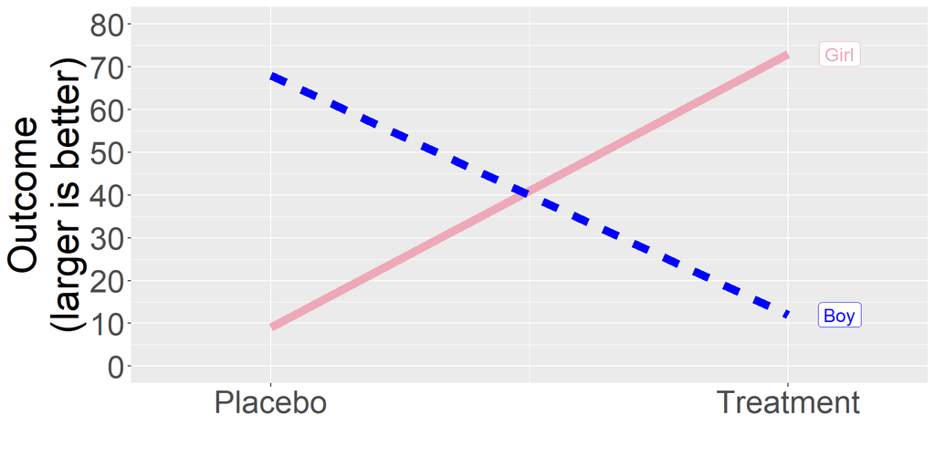

- Significant interaction
- Harmful treatment in boys
- Effective treatment in girls

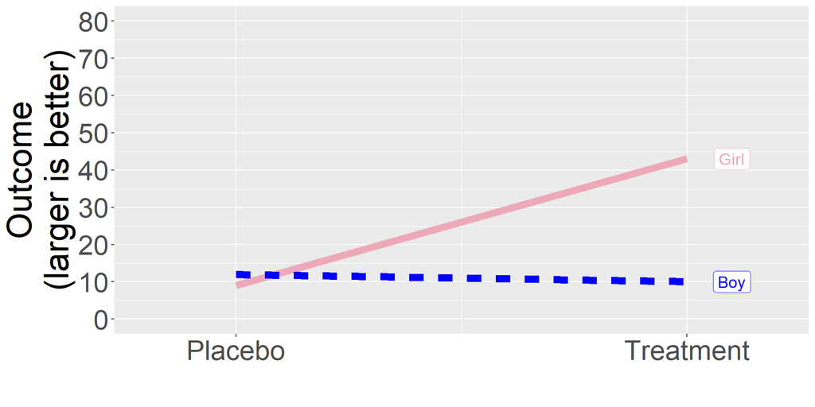

- Significant interaction
- Ineffective treatment in boys
- Effective treatment in girls

## Hypothetical interaction plots, 4 of 4

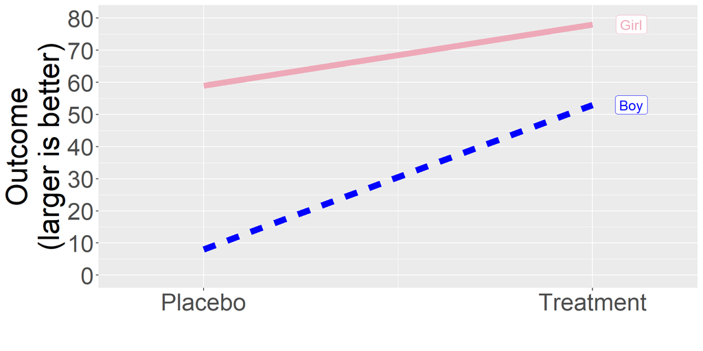

- Significant interaction
- Girls fare better overall
- Effective treatment
- Much more effective in boys

## Group means for tracking data

```
# A tibble: 4 × 3
  child gender mean_trial4
  <fct> <chr>        <dbl>
1 Yes   F             2.57
2 Yes   M             2.54
3 No    F             4.46
4 No    M             6.77
```

## Line plot of tracking data

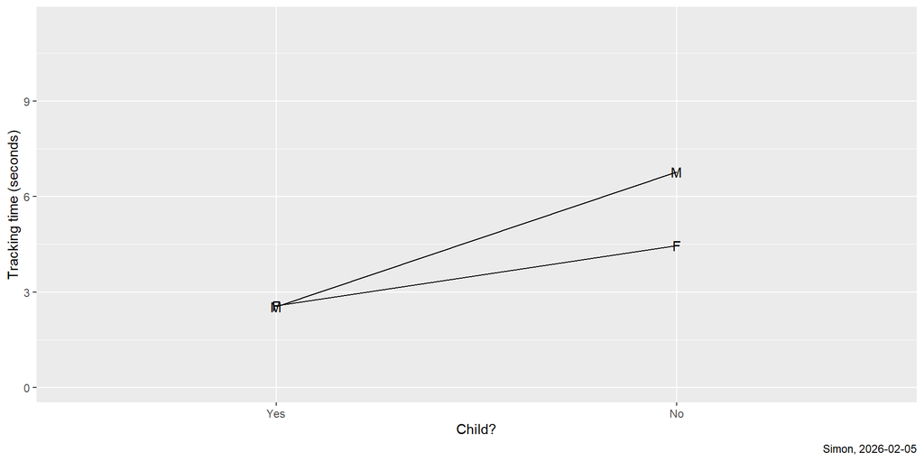

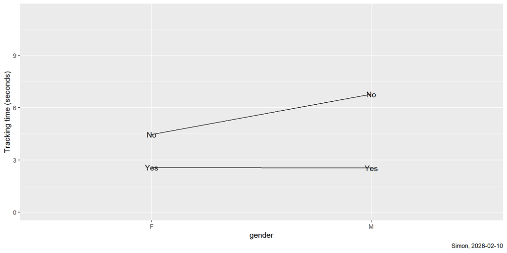

## When you can’t estimate an interaction

- Special case, n=1
  - Only one observation for categorical combination

## Summary

- What you have learned
  - Review one factor analysis of variance
  - Multiple factor analysis of variance
  - Checking assumptions of analysis of variance
  - Interactions in analysis of variance